# Statistical inference with the GSS data

## Setup

### Load packages

```r
library(ggplot2)
library(dplyr)
library(statsr)
```

### Load data

```r
load("gss.Rdata")
```

## Part 1: Data

The GSS is a survey of opinions of the American public. A majority of these data are collected via face-to-face interview or conducted via telephone interview a face-to-face is not possible. The sampling of participants involves blocking for sex, age, and employment status. Sampling and interview techniques are employed in order to ensure that selected participants are at home when the interviewers arrive.

I believe that the data presented in the GSS are generalizable to the U.S. population as a whole. The purpose of this program, which has existed since 1972, is to provide data to researchers, policy makers, and others in order to track the trends of social opinion within the United States as well as to compare the U.S. to other nations. The documentation for the GSS mentions that along with the collection of data, another goal of the GSS is to advance survey methods “in order to insure tha tthe GSS data are of the highest possible quality.” The data were collected via random block sampling therefore allowing for generalizations to the public.

These data are not appropriate for makeing causality judgements. Since these are observational data and not randomly assigned experimental data, we can not infer causality.

## Part 2: Research question

Is there a difference in the amount of time spent watching television between men and women?

I believe that this questions could be of interest to advertisers. If a company is preparing to run a television ad they would want to know what demographic to target with their add. If there are significantly more of one gender watching television it might be most prudent to design their ad in a way that targets that gender.

## Part 3: Exploratory data analysis

First I want to look at a plot of viewership of males and females for all time. This is to determine if I want to use the entire dataset or just a subset.

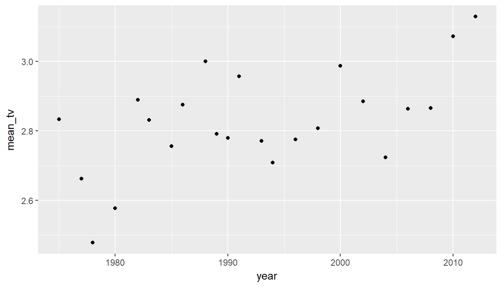

```r
all_years_tv <- gss %>% filter(tvhours != 'NA') %>% group_by(year, sex) %>% summarise(mean_tv = mean(tvhours))
males <- all_years_tv %>% filter(sex == 'Male')
females <- all_years_tv %>% filter(sex == 'Female')

ggplot(males, aes(year, mean_tv)) + geom_point()
```

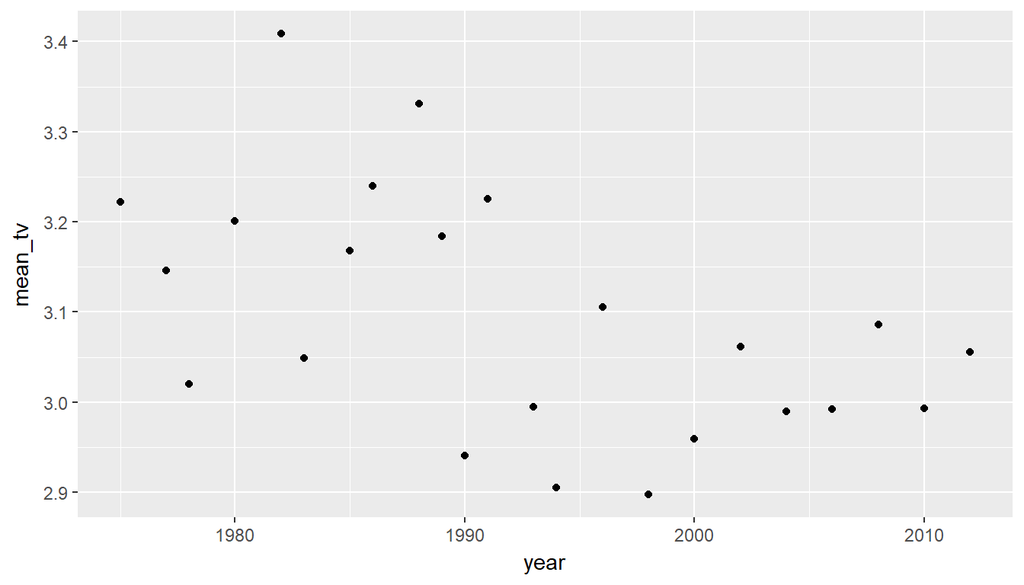

```r
ggplot(females, aes(year, mean_tv)) + geom_point()
```

Based on this I want to subset this to years after and including 2000. This is because female viewership seems to have dropped until about then and has held steady since.

```r
gender_tv_2000 <- gss %>% filter(year >= 2000, tvhours != 'NA') %>% select(sex, tvhours)
```

Now I want to look at summary stats and a boxplot of these data.

```r
summary(gender_tv_2000)
```

```
##      sex          tvhours
##  Male  :4289   Min.   : 0.000
##  Female:5379   1st Qu.: 1.000
##                Median : 2.000
##                Mean   : 2.981
##                3rd Qu.: 4.000
##                Max.   :24.000
```

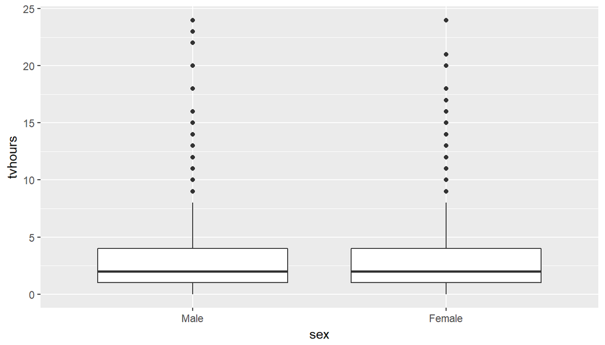

```r
ggplot(gender_tv_2000, aes(sex, tvhours)) + geom_boxplot()
```

There seems to be a similar number of males and females. The median, spread and shape of both series look similar. There are no obvious outliers for one gender that are not apparent in the other.

## Part 4: Inference

### Hypotheses

H0: There is no difference between number of hours of television viewing between men and women (i.e. mu_Male = mu_Female)

HA: There is a difference between men and women in the number of hours that they watch television (i.e. mu_Male != mu_Female)

### Conditions

The condition of independence is met. These are taken from a random sample of the american public and the n for both is less than 10% of the total male and female population respectivly.

The population is most likely skewed right for this metric, but since our sample sizes are 4289 for males and 5379 for females, we should have enough observations to account for that skew.

### 95% Confidence Interval

```r
inference(y = tvhours, x = sex, data = gender_tv_2000, statistic = 'mean', type = 'ci', method = "theoretical")
```

```
## Response variable: numerical, Explanatory variable: categorical (2 levels)
## n_Male = 4289, y_bar_Male = 2.9405, s_Male = 2.6294
## n_Female = 5379, y_bar_Female = 3.0125, s_Female = 2.5529
## 95% CI (Male - Female): (-0.1761 , 0.0323)
```

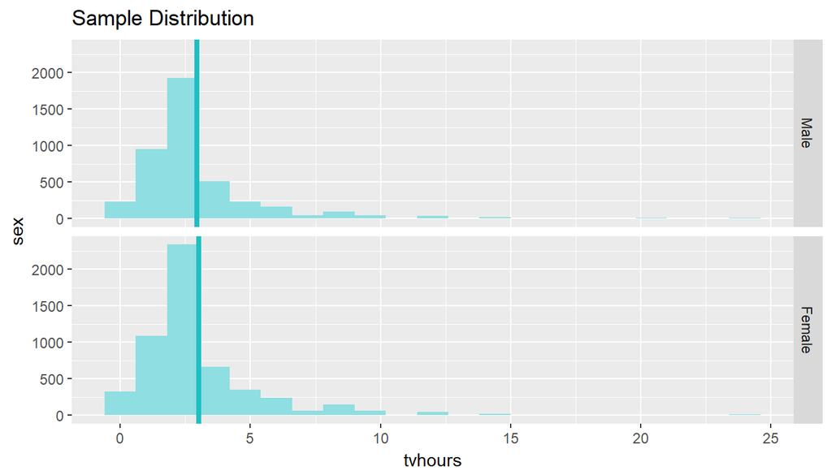

Based on the 95% confidence interval we can expect the true difference in the time spent watching tv for males and females to be between 0.18 hours (~11 minutes) less for males and 0.03 hours (~ 2 minutes) more for males.

### Hypothesis Test

```r
inference(y = tvhours, x = sex, data = gender_tv_2000, statistic = 'mean', type = 'ht', null = 0, method = "theoretical", alternative = 'twosided')
```

```
## Response variable: numerical
## Explanatory variable: categorical (2 levels)
## n_Male = 4289, y_bar_Male = 2.9405, s_Male = 2.6294
## n_Female = 5379, y_bar_Female = 3.0125, s_Female = 2.5529
## H0: mu_Male =  mu_Female
## HA: mu_Male != mu_Female
## t = -1.3533, df = 4288
## p_value = 0.176
```

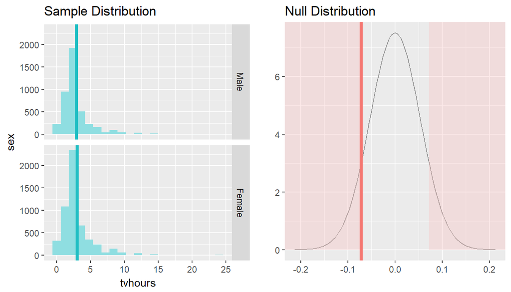

The p-value from the hypothesis test is 0.176. If we are using a typical alpha of 0.05 then based on this p-value we would not reject the null hypothesis. The evidence points to there being no difference in the number of hours men and women spend watching television. This is corroborated by the 95% CI as 0 falls within the confidence interval.

Based on these data. I would advise a company that is designing a television ad to take into consideration that both genders would be equally likely to view their advertisement. There are serious limitations to this reccomendations though. These data only take into account the total number of hours spent watching television. As there are dozens or even hundreds of channels available, this could be misleading. There is no information on whether men and women choose to watch the same channel or even the same program. If the company is making an ad and they don’t get to choose which channels or times the ad runs then I would advise making it gender neutral. But, if they know the exact times or channels that their ad will be run on, then I would suggest doing some further demographic exploration for that particular channel.